# AI - CA5 - Neural Network - Phase 2 - Mohamad Taha Fakharian

## Goal

In this assignment, we're going to train a neural network on a A-Z Handwritten Alphabets dataset. Let's start!

## Overall approach

In order to train the network, we first need to read the datasets, then apply some preprocessing and after that, train the model and see the impact of hyperparameters on the accuracy of the model. Let's import some useful libraries:

```python
import numpy as np
import pandas as pd
import matplotlib.pyplot as plt

from sklearn.model_selection import train_test_split
from sklearn.metrics import classification_report

import tensorflow as tf
from tensorflow.keras import *
from tensorflow.keras.utils import to_categorical

import random

import gc
```

Since we use Google Colab to train the model, we need to upload the dataset on the drive:

```python
from google.colab import drive
drive.mount('/content/drive')
```

## Phase 1: Data preprocessing and visualization

First let's import the dataset:

```python
dataset = pd.read_csv('/content/drive/MyDrive/Uni/Term6/AI/A_Z.csv')
```

Since current dataset takes too much RAM, we need to cast the dataset from 'int16' to 'uint8' to free up some space for furthur processes:

```python
dataset = dataset.astype('uint8')
```

Let's seperate features from labels in the dataset:

```python
X, y = dataset.drop(['0'], axis=1, inplace=False) , dataset['0']
```

Now we can delete dataset to free up some RAM:

```python
del dataset
gc.collect()
```

```
164
```

Let's convert the features to 28*28 arrays to do some visualizations. Note that we'll use current dataframe as the input of the neural network.

```python
images = X.to_numpy()
images = images.reshape((images.shape[0], 28, 28))
```

Let's see a random image from the dataset:

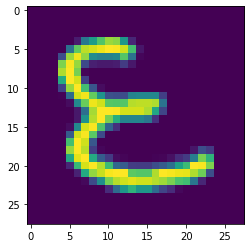

```python
plt.imshow(random.choice(images))
plt.show()
```

Now let's see total number of images and total number of classes in the dataset:

```python
len(y), y.nunique()
```

```
(372450, 26)
```

Note that we have 26 alphabets in English.

Now let's see the bar plot of frequencies of classes in the dataset:

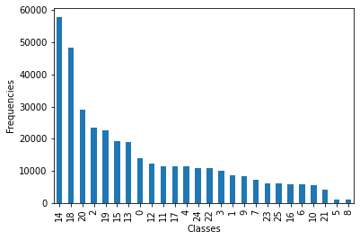

```python
y.value_counts().plot.bar()
plt.xlabel('Classes')
plt.ylabel('Frequencies')
plt.show()
```

```
Class = 0
```

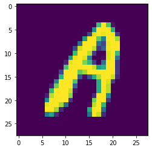

```
Class = 1
```

[figure not shown]

```
Class = 2
```

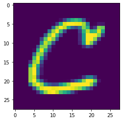

```
Class = 3
```

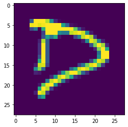

```
Class = 4
```

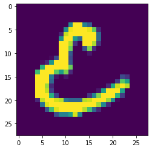

```
Class = 5
```

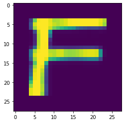

```
Class = 6
```

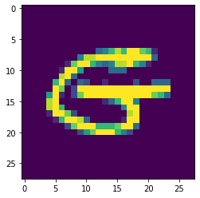

```
Class = 7
```

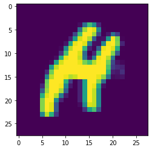

```
Class = 8
```

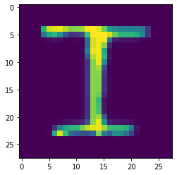

```
Class = 9
```

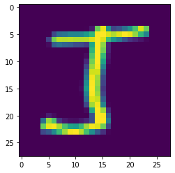

```
Class = 10
```

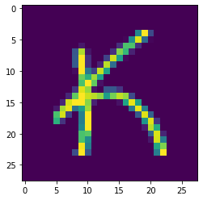

```
Class = 11
```

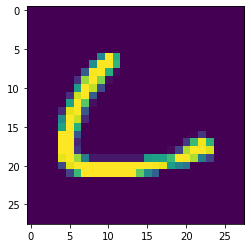

```
Class = 12
```

[14 more figures not shown]

```python
for i in range(26):
  print("Class = {}".format(i))
  index = np.where(y == i)
  plt.imshow(images[index[0][0]])
  plt.show()
  print()
```

We'll delete images to free up some RAM:

```python
del images
gc.collect()
```

```
68036
```

Now we'll split dataset to train and test sets with 7:3 ratio respectively:

```python
X_train, X_test, y_train, y_test = train_test_split(X, y, test_size=0.3)
```

Now we need to perform a one-hot encoding on the target labels. This is because we want to calculate loss function according to output of neural network's last layer, which has a total number of unique classes for neurons, which is possible for multi-class classification tasks:

```python
y_train_cat = to_categorical(y_train)
y_test_cat = to_categorical(y_test)
```

## Phase 2: Designing neural network

First, we need to create a neural network with given parameters using Keras API and see the parameters.

Before that, we'll define two functions to see the classification report of trained model on train and test data and also plot accuracy and loss with respect to epochs:

```python
def report(model, X_train, y_train, X_test, y_test):
  y_pred = model.predict(X_train)
  y_pred = np.argmax(y_pred, axis=1)
  print("Train:")
  print(classification_report(y_train, y_pred))

  y_pred = model.predict(X_test)
  y_pred = np.argmax(y_pred, axis=1)
  print("Test:")
  print(classification_report(y_test, y_pred))
  del y_pred

def plot_results(history):
  fig, (ax1, ax2) = plt.subplots(1, 2, figsize=(10,5))
  plt.tight_layout()

  ax1.set_title("Accuracy")
  ax1.set_ylabel("Accuracy")
  ax1.set_xlabel("Epoch")
  ax1.plot(history.history['accuracy'], label="train")
  ax1.plot(history.history['val_accuracy'], label="test")
  ax1.legend()

  ax2.set_title("Loss")
  ax2.set_ylabel("Loss")
  ax2.set_xlabel("Epoch")
  ax2.plot(history.history['loss'], label="train")
  ax2.plot(history.history['val_loss'], label="test")
  ax2.legend()
  plt.show()
```

Now we'll create a neural network with given parameters using Sequential model of Keras API:

```python
model = models.Sequential()
model.add(layers.Dense(50, input_dim=784, activation=activations.relu))
model.add(layers.Dense(30, activation=activations.relu))
model.add(layers.Dense(26, activation=activations.softmax))

model.compile(optimizer=optimizers.SGD(learning_rate=0.01), loss=losses.categorical_crossentropy, metrics=["accuracy"])
```

Let's see the parameters of this model:

```python
model.summary()
```

```
Model: "sequential"
_________________________________________________________________
 Layer (type)                Output Shape              Param #
=================================================================
 dense (Dense)               (None, 50)                39250

 dense_1 (Dense)             (None, 30)                1530

 dense_2 (Dense)             (None, 26)                806

=================================================================
Total params: 41,586
Trainable params: 41,586
Non-trainable params: 0
_________________________________________________________________
```

Note that from now on, we'll delete model and anything related to that after we're finished with it and we'll collect garbage collector to free space for next phases:

```python
del model
gc.collect()
```

```
638
```

Total parameters of layer i is equal to dimension of layer (i-1) *dimension of layer i(for weight's matrix) + dimension of layer i. In this way, parameters of layer 1 is (784* 50) + 50 = 39250, layer 2 is (50 *30) + 30 = 1530 and layer 3 is (30* 26) + 26 = 806.

## Phase 3: Data classification

We need to perform normalization on features for better performance in neural network. We'll divide features by 255:

```python
X_train = X_train.div(255)
X_test = X_test.div(255)
```

Before training any models, we'll check if gpu is available:

```python
tf.test.gpu_device_name()
```

```
'/device:GPU:0'
```

```python
model = models.Sequential()
model.add(layers.Dense(100, input_dim=784, activation=layers.LeakyReLU(alpha=0.01)))
model.add(layers.Dense(50, activation=layers.LeakyReLU(alpha=0.01)))
model.add(layers.Dense(26, activation=activations.softmax))

model.compile(optimizer=optimizers.SGD(learning_rate=0.01), loss=losses.categorical_crossentropy, metrics=["accuracy"])
```

Let's fit the model and see the results:

```python
history = model.fit(X_train, y_train_cat, validation_data=(X_test, y_test_cat), epochs=10, batch_size=32)
```

```python
report(model, X_train, y_train, X_test, y_test)
```

```
Train:
              precision    recall  f1-score   support

           0       0.97      0.96      0.97      9716
           1       0.96      0.94      0.95      6088
           2       0.97      0.98      0.98     16326
           3       0.93      0.93      0.93      7127
           4       0.97      0.96      0.96      8066
           5       0.94      0.93      0.93       823
           6       0.95      0.91      0.93      4002
           7       0.97      0.89      0.93      5041
           8       0.98      0.91      0.94       789
           9       0.95      0.94      0.95      5919
          10       0.95      0.93      0.94      3863
          11       0.97      0.98      0.97      8118
```

[output cut: 52 more lines]

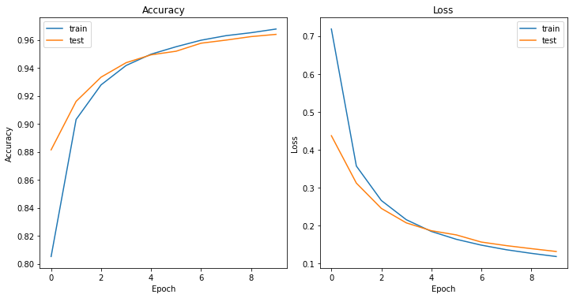

```python
plot_results(history)
```

```python
del model
del history
gc.collect()
```

```
6964
```

## Phase 4: Impact of hyperparameters on performance

### Optimizer

#### Momentum

Momentum is an extension to the gradient descent optimization algorithm, often referred to as gradient descent with momentum.

It is designed to accelerate the optimization process, e.g. decrease the number of function evaluations required to reach the optima, or to improve the capability of the optimization algorithm, e.g. result in a better final result.

Momentum involves adding an additional hyperparameter that controls the amount of history (momentum) to include in the update equation, i.e. the step to a new point in the search space. The value for the hyperparameter is defined in the range 0.0 to 1.0 and often has a value close to 1.0, such as 0.8, 0.9, or 0.99. A momentum of 0.0 is the same as gradient descent without momentum.

##### Momentum = 0.5

```python
model = models.Sequential()
model.add(layers.Dense(100, input_dim=784, activation=layers.LeakyReLU(alpha=0.01)))
model.add(layers.Dense(50, activation=layers.LeakyReLU(alpha=0.01)))
model.add(layers.Dense(26, activation=activations.softmax))

model.compile(optimizer=optimizers.SGD(learning_rate=0.01, momentum=0.5), loss=losses.categorical_crossentropy, metrics=["accuracy"])
```

```python
history = model.fit(X_train, y_train_cat, validation_data=(X_test, y_test_cat), epochs=10, batch_size=32)
```

```python
report(model, X_train, y_train, X_test, y_test)
```

```
Train:
              precision    recall  f1-score   support

           0       0.99      0.96      0.98      9716
           1       0.95      0.97      0.96      6088
           2       0.98      0.98      0.98     16326
           3       0.93      0.96      0.94      7127
           4       0.98      0.97      0.97      8066
           5       0.97      0.96      0.96       823
           6       0.96      0.94      0.95      4002
           7       0.97      0.94      0.96      5041
           8       0.95      0.96      0.95       789
           9       0.97      0.96      0.96      5919
          10       0.94      0.97      0.95      3863
          11       0.98      0.98      0.98      8118
```

[output cut: 52 more lines]

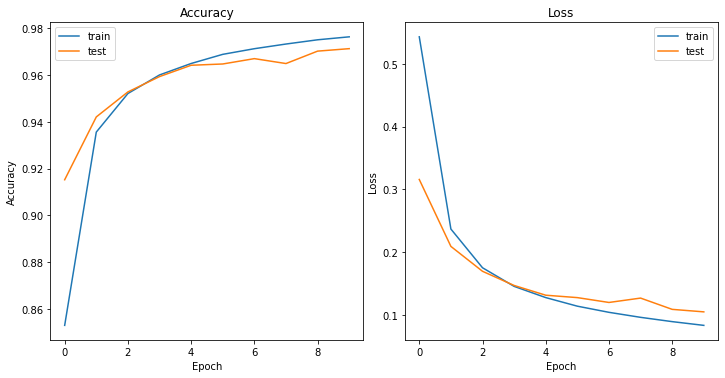

```python
plot_results(history)
```

```python
del model
del history
gc.collect()
```

```
8537
```

##### Momentum = 0.9

```python
model = models.Sequential()
model.add(layers.Dense(100, input_dim=784, activation=layers.LeakyReLU(alpha=0.01)))
model.add(layers.Dense(50, activation=layers.LeakyReLU(alpha=0.01)))
model.add(layers.Dense(26, activation=activations.softmax))

model.compile(optimizer=optimizers.SGD(learning_rate=0.01, momentum=0.9), loss=losses.categorical_crossentropy, metrics=["accuracy"])
```

```python
history = model.fit(X_train, y_train_cat, validation_data=(X_test, y_test_cat), epochs=10, batch_size=32)
```

```python
report(model, X_train, y_train, X_test, y_test)
```

```
Train:
              precision    recall  f1-score   support

           0       0.99      0.98      0.98      9716
           1       0.99      0.98      0.98      6088
           2       0.98      0.99      0.99     16326
           3       0.94      0.96      0.95      7127
           4       0.98      0.98      0.98      8066
           5       0.98      0.96      0.97       823
           6       0.99      0.94      0.97      4002
           7       0.97      0.97      0.97      5041
           8       0.99      0.94      0.97       789
           9       0.99      0.95      0.97      5919
          10       0.98      0.96      0.97      3863
          11       0.98      0.99      0.98      8118
```

[output cut: 52 more lines]

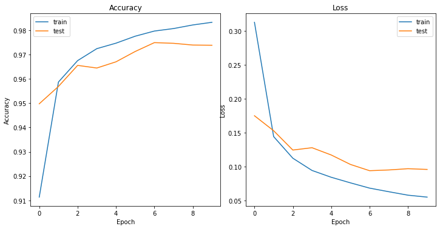

```python
plot_results(history)
```

```python
del model
del history
gc.collect()
```

```
8711
```

##### Momentum = 0.98

```python
model = models.Sequential()
model.add(layers.Dense(100, input_dim=784, activation=layers.LeakyReLU(alpha=0.01)))
model.add(layers.Dense(50, activation=layers.LeakyReLU(alpha=0.01)))
model.add(layers.Dense(26, activation=activations.softmax))

model.compile(optimizer=optimizers.SGD(learning_rate=0.01, momentum=0.98), loss=losses.categorical_crossentropy, metrics=["accuracy"])
```

```python
history = model.fit(X_train, y_train_cat, validation_data=(X_test, y_test_cat), epochs=10, batch_size=32)
```

```python
report(model, X_train, y_train, X_test, y_test)
```

```
Train:
              precision    recall  f1-score   support

           0       0.96      0.97      0.97      9716
           1       0.98      0.93      0.95      6088
           2       0.96      0.99      0.98     16326
           3       0.90      0.95      0.92      7127
           4       0.97      0.95      0.96      8066
           5       0.97      0.92      0.95       823
           6       0.95      0.94      0.95      4002
           7       0.96      0.92      0.94      5041
           8       0.99      0.87      0.93       789
           9       0.93      0.96      0.95      5919
          10       0.92      0.93      0.93      3863
          11       0.97      0.97      0.97      8118
```

[output cut: 52 more lines]

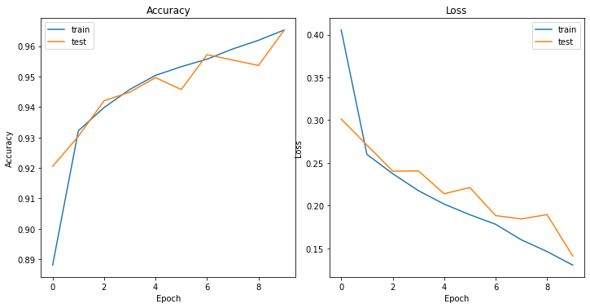

```python
plot_results(history)
```

```python
del model
del history
gc.collect()
```

```
8711
```

As you can see, using 0.9 for momentum helped the model converge to the minimum faster and better, but using greater value for momentum didn't helped it and resulted in poor performance, compared to previous momentum.

Momentum in neural nets helps them get out of local minima points so that a more important global minimum is found. Too much of momentum may create issues as well as systems that are not stable may create oscillations that grow in magnitude, in such cases one needs to add decay terms and so on. It's just physics applied to neural net training or numerical optimizations.

#### Adam

Adam is an adaptive deep neural network training optimizer that has been widely used across a variety of applications. However, on image classification problems, its generalization performance is significantly worse than stochastic gradient descent (SGD). By tuning several inner hyperparameters of Adam, it is possible to lift the performance of Adam and close this gap; but this makes the use of Adam computationally expensive.

Let's see the results using Adam optimizer:

```python
model = models.Sequential()
model.add(layers.Dense(100, input_dim=784, activation=layers.LeakyReLU(alpha=0.01)))
model.add(layers.Dense(50, activation=layers.LeakyReLU(alpha=0.01)))
model.add(layers.Dense(26, activation=activations.softmax))

model.compile(optimizer=optimizers.Adam(learning_rate=0.001), loss=losses.categorical_crossentropy, metrics=["accuracy"])
```

```python
history = model.fit(X_train, y_train_cat, validation_data=(X_test, y_test_cat), epochs=10, batch_size=32)
```

```python
report(model, X_train, y_train, X_test, y_test)
```

```
Train:
              precision    recall  f1-score   support

           0       0.99      0.98      0.99      9716
           1       0.98      0.99      0.98      6088
           2       0.98      0.99      0.99     16326
           3       0.97      0.96      0.97      7127
           4       0.99      0.98      0.99      8066
           5       0.97      0.99      0.98       823
           6       0.96      0.98      0.97      4002
           7       0.96      0.99      0.97      5041
           8       0.92      0.99      0.95       789
           9       0.99      0.96      0.97      5919
          10       0.97      0.98      0.98      3863
          11       1.00      0.97      0.98      8118
```

[output cut: 52 more lines]

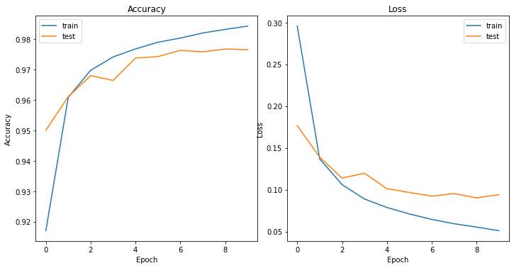

```python
plot_results(history)
```

```python
del model
del history
gc.collect()
```

```
8653
```

#### Epoch

If we train the network for a few epochs, it leads to underfitting of the data. This means the neural network cannot capture the underlying trend of the data. Now, as we increase the number of epochs, it will reach an optimal situation where we will get maximum accuracy on the training set. Beyond this stage, if we keep increasing the number of epochs, it will lead to overfitting of the data. That is the accuracy in the training set increases whereas that of validation set decreases. This means the network does not reflect the reality of the data because it captures the noise in the data as well.

To avoid overfitting, we can perform change architecture or use early stopping in training:

- Change network complexity by changing the network structure (number of weights).
- Change network complexity by changing the network parameters (values of weights).
- Activity Regularization: Penalize the model during training base on the magnitude of the activations.
- Weight Constraint: Constrain the magnitude of weights to be within a range or below a limit.
- Dropout: Probabilistically remove inputs during training.
- Noise: Add statistical noise to inputs during training.
- Early Stopping: Monitor model performance on a validation set and stop training when performance degrades.

Let's see the results using 20 epochs for training:

```python
model = models.Sequential()
model.add(layers.Dense(100, input_dim=784, activation=layers.LeakyReLU(alpha=0.01)))
model.add(layers.Dense(50, activation=layers.LeakyReLU(alpha=0.01)))
model.add(layers.Dense(26, activation=activations.softmax))

model.compile(optimizer=optimizers.Adam(learning_rate=0.001), loss=losses.categorical_crossentropy, metrics=["accuracy"])
```

```python
history = model.fit(X_train, y_train_cat, validation_data=(X_test, y_test_cat), epochs=20, batch_size=32)
```

```python
report(model, X_train, y_train, X_test, y_test)
```

```
Train:
              precision    recall  f1-score   support

           0       1.00      0.98      0.99      9716
           1       0.99      0.97      0.98      6088
           2       0.98      1.00      0.99     16326
           3       0.97      0.96      0.96      7127
           4       1.00      0.98      0.99      8066
           5       1.00      0.97      0.98       823
           6       0.99      0.98      0.98      4002
           7       0.98      0.98      0.98      5041
           8       1.00      0.98      0.99       789
           9       0.99      0.98      0.99      5919
          10       0.95      0.99      0.97      3863
          11       1.00      0.98      0.99      8118
```

[output cut: 52 more lines]

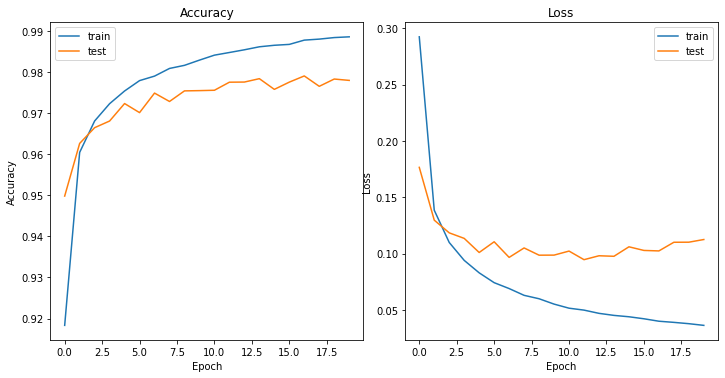

```python
plot_results(history)
```

```python
del model
del history
gc.collect()
```

```
9107
```

As you can see, the final epoch changed accuracy on train data higher than test data and can be a sign of overfitting in model.

#### Loss function

There are two reasons why Mean Squared Error(MSE) is a bad choice for binary classification problems:

First, using MSE means that we assume that the underlying data has been generated from a normal distribution (a bell-shaped curve). In Bayesian terms this means we assume a Gaussian prior. While in reality, a dataset that can be classified into two categories (i.e binary) is not from a normal distribution but a Bernoulli distribution.

Secondly, the MSE function is non-convex for binary classification. In simple terms, if a binary classification model is trained with MSE Cost function, it is not guaranteed to minimize the Cost function. This is because MSE function expects real-valued inputs in range(-∞, ∞), while binary classification models output probabilities in range(0,1) through the sigmoid/logistic function.

The Mean Squared Error is used as a default metric for evaluation of the performance of most regression algorithms.

Let's see the results using mse loss function:

```python
model = models.Sequential()
model.add(layers.Dense(100, input_dim=784, activation=layers.LeakyReLU(alpha=0.01)))
model.add(layers.Dense(50, activation=layers.LeakyReLU(alpha=0.01)))
model.add(layers.Dense(26, activation=activations.softmax))

model.compile(optimizer=optimizers.Adam(learning_rate=0.001), loss="mse", metrics=["accuracy"])
```

```python
history = model.fit(X_train, y_train_cat, validation_data=(X_test, y_test_cat), epochs=10, batch_size=32)
```

```python
report(model, X_train, y_train, X_test, y_test)
```

```
Train:
              precision    recall  f1-score   support

           0       0.95      0.99      0.97      9716
           1       0.97      0.97      0.97      6088
           2       0.98      0.99      0.98     16326
           3       0.91      0.97      0.94      7127
           4       0.98      0.97      0.98      8066
           5       0.88      0.98      0.93       823
           6       0.96      0.96      0.96      4002
           7       0.98      0.91      0.95      5041
           8       0.96      0.91      0.94       789
           9       0.97      0.95      0.96      5919
          10       0.99      0.92      0.95      3863
          11       0.99      0.97      0.98      8118
```

[output cut: 52 more lines]

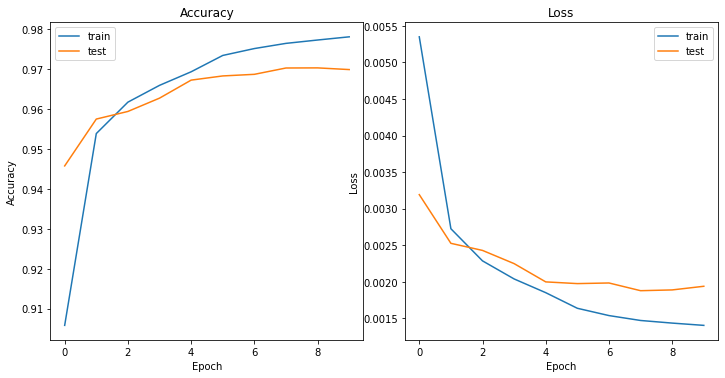

```python
plot_results(history)
```

We can see that the result is a bit worse than the categorical cross entropy.

```python
del model
del history
gc.collect()
```

```
8948
```

#### Regularization

##### L2 Regularization

Briefly, L2 regularization works by adding a term to the error function used by the training algorithm. The additional term penalizes large weight values. The two most common error functions used in neural network training are squared error and cross entropy error.

Let's see the results using l2 regularization:

```python
model = models.Sequential()
model.add(layers.Dense(100, input_dim=784, activation=layers.LeakyReLU(alpha=0.01), kernel_regularizer=regularizers.l2(0.0001)))
model.add(layers.Dense(50, activation=layers.LeakyReLU(alpha=0.01), kernel_regularizer=regularizers.l2(0.0001)))
model.add(layers.Dense(26, activation=activations.softmax, kernel_regularizer=regularizers.l2(0.0001)))

model.compile(optimizer=optimizers.Adam(learning_rate=0.001), loss=losses.categorical_crossentropy, metrics=["accuracy"])
```

```python
history = model.fit(X_train, y_train_cat, validation_data=(X_test, y_test_cat), epochs=20, batch_size=32)
```

```python
report(model, X_train, y_train, X_test, y_test)
```

```
Train:
              precision    recall  f1-score   support

           0       0.97      0.98      0.97      9716
           1       0.94      0.97      0.95      6088
           2       0.98      0.99      0.98     16326
           3       0.97      0.89      0.93      7127
           4       0.98      0.96      0.97      8066
           5       0.97      0.96      0.97       823
           6       0.98      0.94      0.96      4002
           7       0.97      0.94      0.96      5041
           8       0.99      0.89      0.94       789
           9       0.97      0.96      0.96      5919
          10       0.95      0.96      0.96      3863
          11       0.98      0.98      0.98      8118
```

[output cut: 52 more lines]

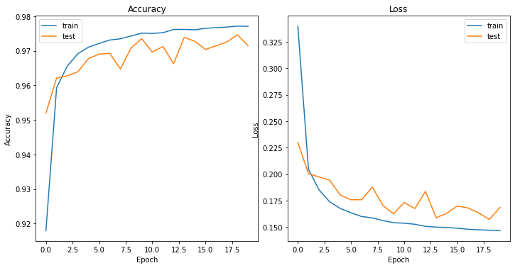

```python
plot_results(history)
```

```python
del model
del history
gc.collect()
```

```
9165
```

##### Dropout

Dropout is a regularization method that approximates training a large number of neural networks with different architectures in parallel.

During training, some number of layer outputs are randomly ignored or “dropped out.” This has the effect of making the layer look-like and be treated-like a layer with a different number of nodes and connectivity to the prior layer. In effect, each update to a layer during training is performed with a different “view” of the configured layer.

Dropout has the effect of making the training process noisy, forcing nodes within a layer to probabilistically take on more or less responsibility for the inputs.

Dropout forces a neural network to learn more robust features that are useful in conjunction with many different random subsets of the other neurons. Dropout roughly doubles the number of iterations required to converge.

```python
model = models.Sequential()
model.add(layers.Dense(100, input_dim=784, activation=layers.LeakyReLU(alpha=0.01)))
model.add(layers.Dropout(rate=0.1))
model.add(layers.Dense(50, activation=layers.LeakyReLU(alpha=0.01)))
model.add(layers.Dropout(rate=0.1))
model.add(layers.Dense(26, activation=activations.softmax))

model.compile(optimizer=optimizers.Adam(learning_rate=0.001), loss=losses.categorical_crossentropy, metrics=["accuracy"])
```

```python
history = model.fit(X_train, y_train_cat, validation_data=(X_test, y_test_cat), epochs=20, batch_size=32)
```

```python
report(model, X_train, y_train, X_test, y_test)
```

```
Train:
              precision    recall  f1-score   support

           0       0.98      0.99      0.99      9716
           1       0.99      0.97      0.98      6088
           2       0.99      0.99      0.99     16326
           3       0.94      0.97      0.96      7127
           4       0.99      0.98      0.98      8066
           5       0.96      0.99      0.98       823
           6       0.95      0.97      0.96      4002
           7       0.96      0.96      0.96      5041
           8       0.96      0.98      0.97       789
           9       0.98      0.96      0.97      5919
          10       0.97      0.97      0.97      3863
          11       0.98      0.99      0.99      8118
```

[output cut: 52 more lines]

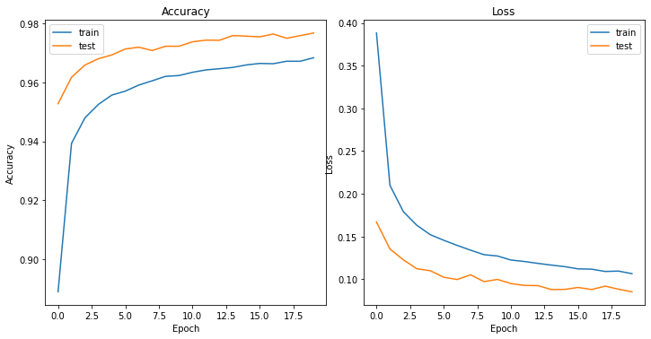

```python
plot_results(history)
```

As you can see, adding dropout resulted in improvement in test data and better generalization.

```python
del model
del history
gc.collect()
```

```
9045
```